# Project Description

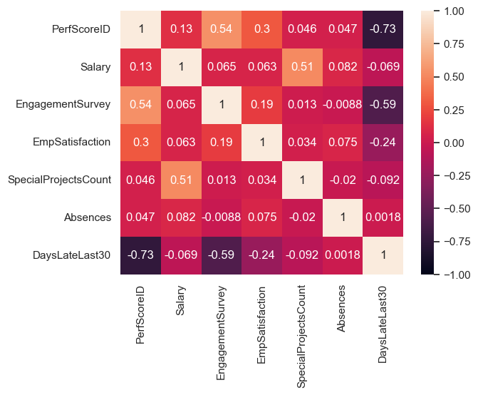

```python
r = df.loc[:,["PerfScoreID","Salary","EngagementSurvey","EmpSatisfaction","SpecialProjectsCount","Absences","DaysLateLast30"]]


sns.heatmap(r.corr(),vmin = -1,vmax = 1,annot = True);
```

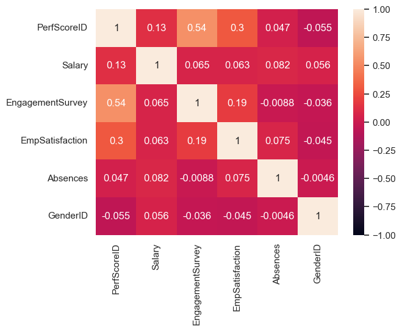

```python
r = df.loc[:,["PerfScoreID","Salary","EngagementSurvey","EmpSatisfaction","Department","Absences","GenderID"]]

sns.heatmap(r.corr(),vmin = -1,vmax = 1,annot = True);
```

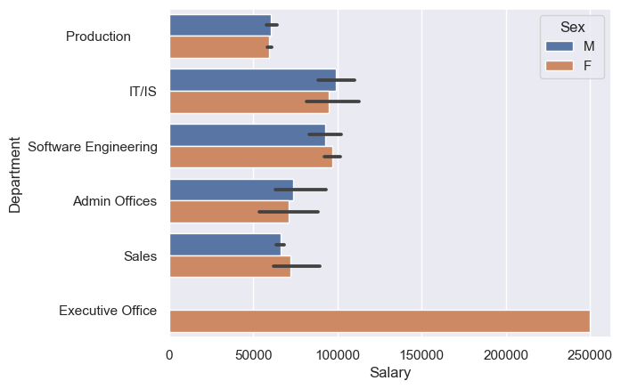

```python
sns.barplot(df,y ="Department",x ="Salary",hue = "Sex")
```

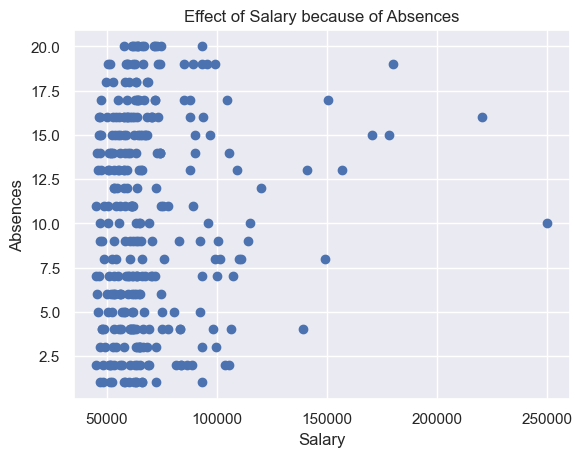

```python
plt.scatter(df['Salary'], df['Absences'])
plt.xlabel('Salary')
plt.ylabel('Absences')
plt.title('Effect of Salary because of Absences')
plt.show()
```

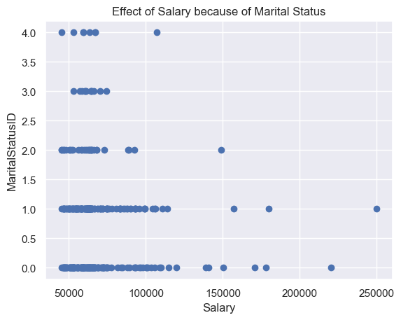

```python
plt.scatter(df['Salary'], df['MaritalStatusID'])
plt.xlabel('Salary')
plt.ylabel('MaritalStatusID')
plt.title('Effect of Salary because of Marital Status')
plt.show()
```

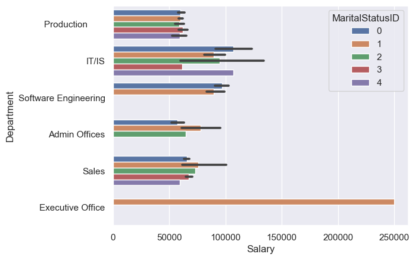

```python
sns.barplot(df,y ="Department",x ="Salary",hue = "MaritalStatusID")
```

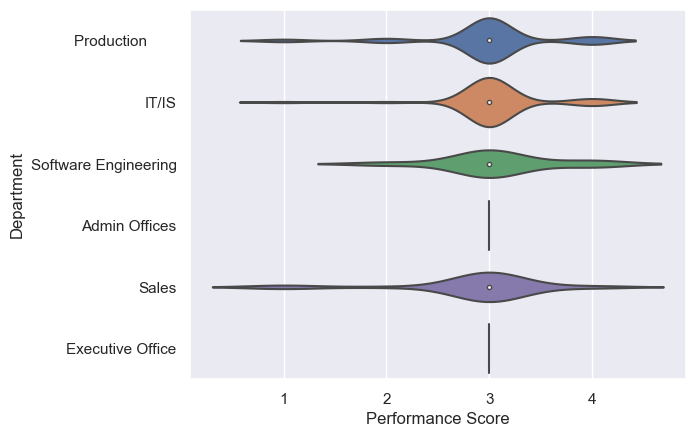

```python
sns.violinplot(data = df,y = "Department", x = "PerfScoreID")
plt.ylabel('Department')

plt.xlabel('Performance Score')
```

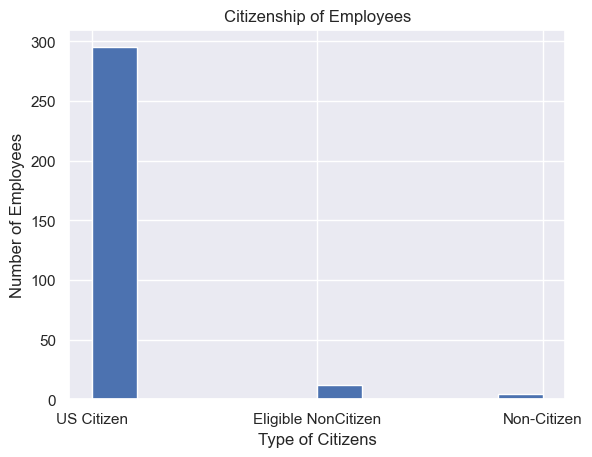

```python
#Recruting diversity analysis based on citizenship

plt.hist(df['CitizenDesc'])
plt.title('Citizenship of Employees')
plt.xlabel('Type of Citizens')
plt.ylabel('Number of Employees')
```

The US Citizens aregot hired more in the company, this is not diversity freindly.

# Conclusion

1. Most of the employees in the company earn between 50000 and 7000 p.a.
2. The production department is the largest one, followed by IT and finally Sales.
3. Around 80% of the employees fully meet their performance requirements.
4. The company needs to be more open to international employees. The reputation of the company must be considered.
5. The IT department has the highest rate of employee turnover. Therefore, recruitment teams should evaluate the hiring process for the IT department.